# 중간고사 BMI 편

통계적 방법론

2016-04-18

학번 ________________

이름 ________________

1. 다음 중 `plot(rn96$height, rn96$weight)` 의 결과로 적합한 것은 무엇인가?

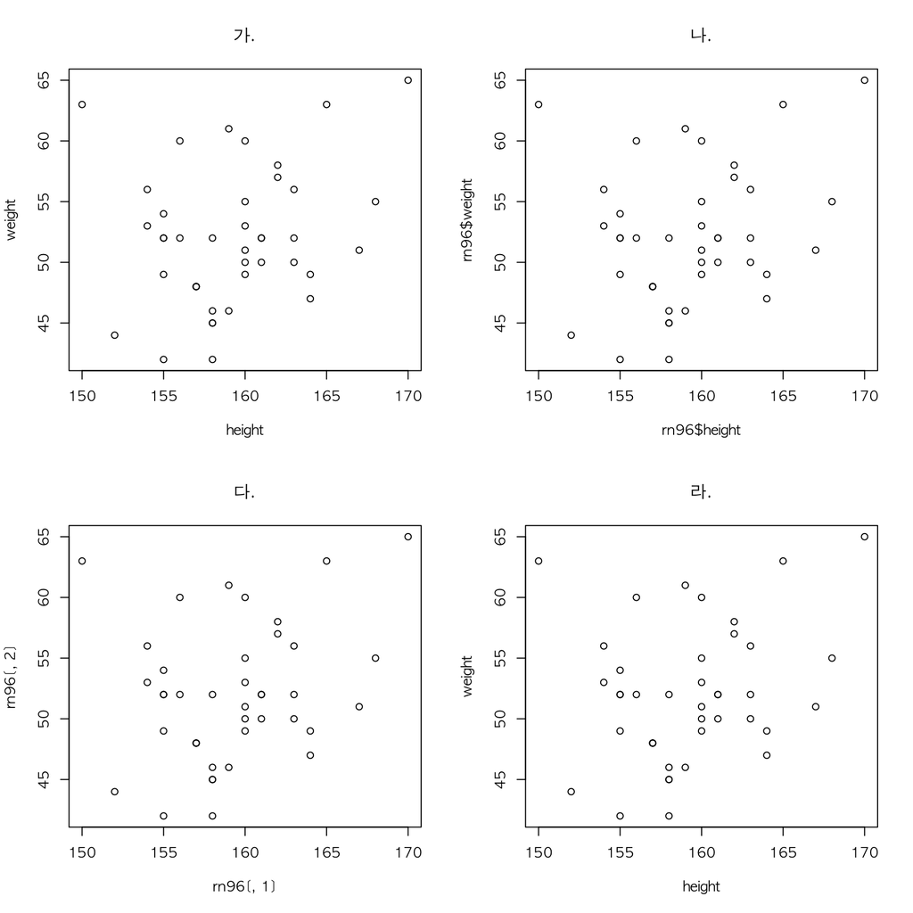

2. 다음 산점도에 회귀선을 그리는 데 적합한 것은 무엇인가?

   가. `lines(lm(weight ~ height, data = rn96)$coefficient)`

   나. `points(lm(weight ~ height, data = rn96)$coefficient)`

   다. `abline(lm(weight ~ height, data = rn96)$coefficient)`

   라. `polygon(lm(weight ~ height, data = rn96)$coefficient)`

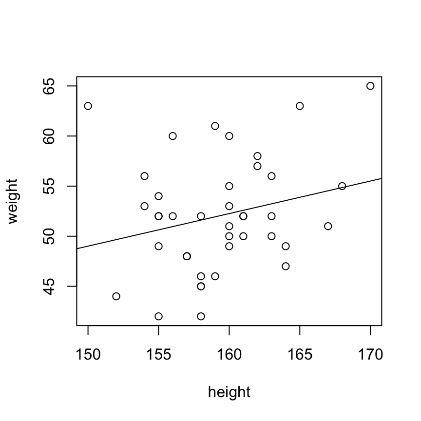

3. 1차 회귀식으로는 살피기 힘든 국소적인 변화를 살피기 위하여 붉은 색으로 local smoother를 추가한다. 이 때 적합한 것은?

   가. `lines(lowess(rn96$height, rn96$weight), col = "red")`

   나. `points(lowess(rn96$height, rn96$weight), col = "red")`

   다. `abline(lowess(rn96$height, rn96$weight), col = "red")`

   라. `polygon(lowess(rn96$height, rn96$weight), col = "red")`

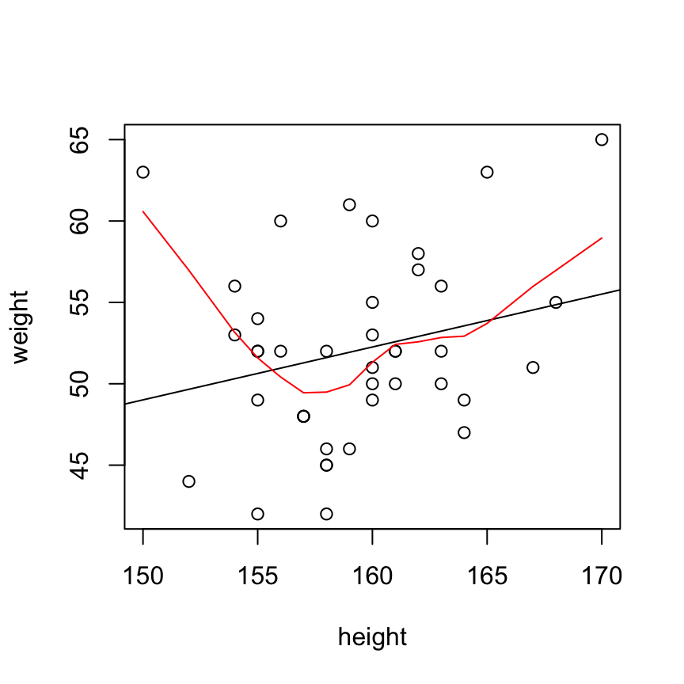

4. 다음 중 그 결과가 다른 것 하나를 고르시오.

   가. `rn96$height`

   나. `rn96[, 1]`

   다. `rn96[, "height"]`

   라. `rn96["height"]`
5. BMI 를 토대로 한 비만도 판정은 “18.5 미만은 underweight, 18.5 ~ 24.9 는 Normal, 25 ~ 29.9 는 Overweight, 30 이상은 Obese” 이다. 이 때, `rn96` 에 판정결과를 덧붙이기 위하여 작성한 다음 코드에서 괄호 자리에 적당한 R 함수는 무엇인가?

   가. `ifelse`

   나. `if`

   다. `for`

   라. `while`

```
rn96$BMI <- BMI
(rn96$obesity <- (      )(BMI < 18.5, "Underweight", (      )(BMI >= 18.5 & BMI < 24.9, "Normal", (     )(BMI >= 25 & BMI < 29.9, "Overweight", "Obese"))))
```